# AlessandroKerr_A4

Alessandro Kerr

Oct 19, 2021

# 6-POINT WORK

In the first section, an equity analysis of educational attainment was completed for Santa Clara County. The data stemmed from 2019 ACS 5-year summary data. The C15002 group of data was used across all races, which is “sex by educational attainment for the population 25 years and older”. For this purpose, the sex data was ignored. The results for the “stacked” and “filled” chart can be seen below.

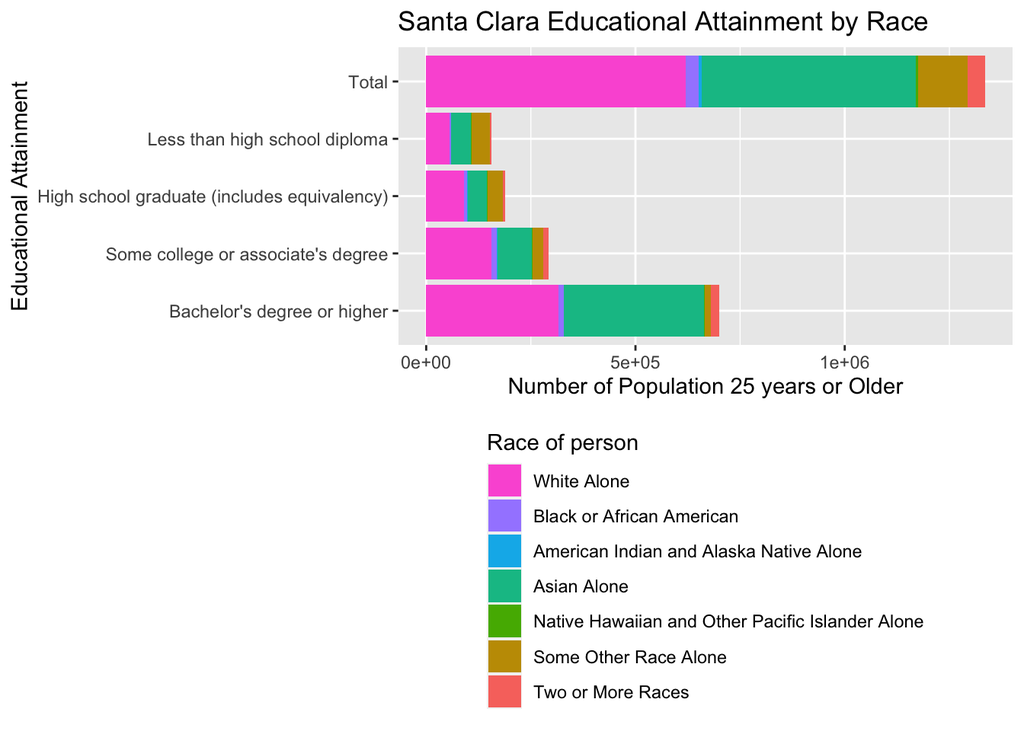

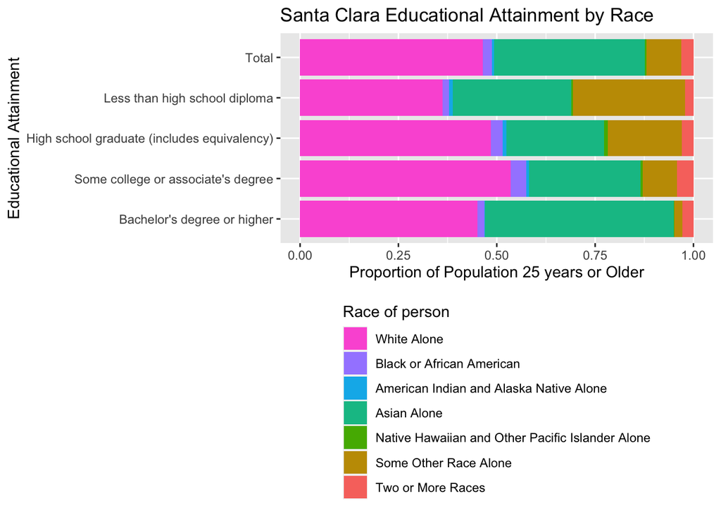

There are several takeaways from the above charts pertaining to the over- and under-representation of racial groups. Firstly, based on the “stacked” chart, the majority of educational attainment lies within the “White” and “Asian” populations. The “filled” chart gives a better idea of races with low total representation through the use of percentages. In particular, it gives better ideas relating to the over- and under-representation of groups. In the “stacked” chart, the white group looks over represented. However, upon further analysis of the “filled” chart, the “Bachelor’s degree category is actually very close to the same percentage of total education, much like many of the”white" categories. Conversely, it can be seen that “Asian” race is over-represented for Bachelor’s degrees. Whereas “some other race” is over-represented in “less than highschool” and under-represented in “Bachelor’s degrees”.

#6.5 POINT WORK

The next task related to completing a similar analysis but breaking down the races into “Latinx”, “White, Not Latinx”, and “Not White, Not LatinX”. Using these three categories allowed for data to be switched from ACS 5-year to 1-year data. The results for the “filled” and “stacked” charts can be seen below.

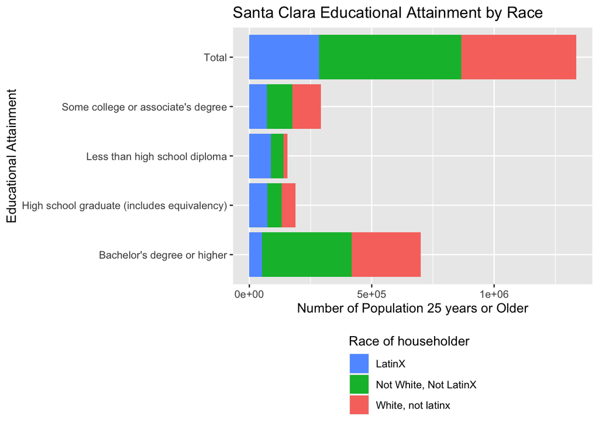

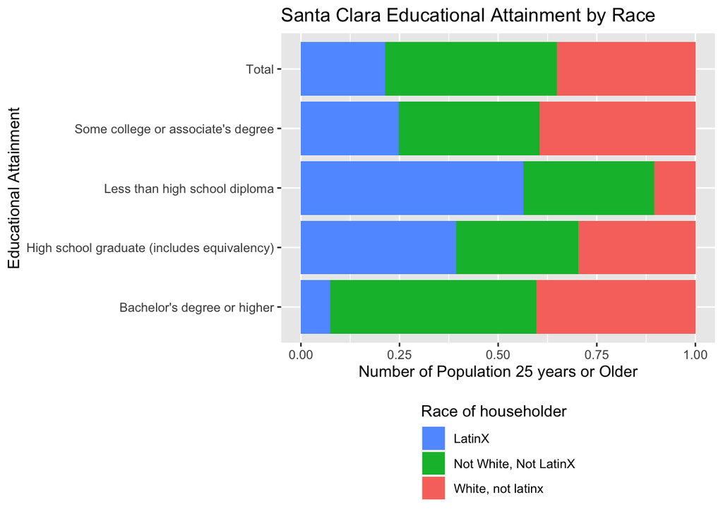

#7-POINT WORK

Finally, the last task expanded the ethnicity analysis to all counties in the Bay Area, and to the years 2006-2019. The goal of this section was to plot the over-representation of the LatinX population (over 25 years old) who have no college degree. This required obtaining the LatinX data, and filtering for those who have not received a college degree. From here, the total number of people who have no college degree was determined; allowing for the ratio of LatinX/Total population who have no college degree. Lastly, the percent of LatinX people in the population was determined. This allowed for the two percentages to be compared to determine the over-representation of LatinX people who have no college degree. The data was plotted for the years 2006-2019 for each county in the Bay Area.

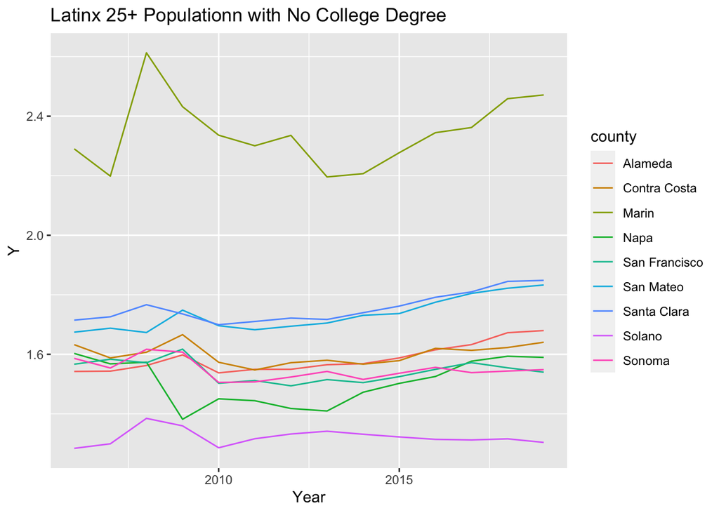